# CDA HW 5

Joshua Ingram

October 8, 2019

# 1.

```r
vector <- c(255,871,128,2614)
police.counts.matrix <- matrix(vector, ncol = 2, nrow = 2)
police.counts.matrix
```

```
##      [,1] [,2]
## [1,]  255  128
## [2,]  871 2614
```

### a.

Multinomail sampling was used because the groups of interest, blacks and whites, were not given fixed row counts.

### b.

```r
addmargins(police.counts.matrix)
```

```
##                Sum
##      255  128  383
##      871 2614 3485
## Sum 1126 2742 3868
```

```r
pos.black <- 128
pos.white <- 2614
pos.black.cond <- pos.black/383
pos.white.cond <- pos.white/3485
pos.black.cond
```

```
## [1] 0.3342037
```

```r
pos.white.cond
```

```
## [1] 0.7500717
```

```r
diff.prop <- pos.white.cond - pos.black.cond
diff.prop
```

```
## [1] 0.4158681
```

$\hat\pi_1$ = estimated proportion of white people that have positive views of local police $\hat\pi_2$ = estimated proportion of black people that have positive views of local police

$\hat\pi_1$ - $\hat\pi_2$ = .4159

We estimate that the proportion of white people that have a positive view of local police is 41.59 percentage points greater than the proportion of blacks that have positive views of the local police.

### c.

```r
diffscoreci(x1 = 2614, n1 = 3485, x2 = 128, n2 = 383, conf.level = .95)
```

```
##
##
##
## data:
##
## 95 percent confidence interval:
##  0.3651276 0.4635483
```

We are 95% confident that the true proportion of white people that have a positive view of local police is between 36.51 and 46.35 percentage points greater than the proportion of blacks that have positive view of the local police.

### d.

$\pi_1$ = proportion of white people that have positive views of local police $\pi_2$ = proportion of black people that have positive views of local police

H0: $\pi_1$ - $\pi_2$ = 0

Ha: $\pi_1$ - $\pi_2$ =/= 0

$\alpha$ = .05

```r
prop.test(c(2614, 128), c(3485, 383), conf.level = .95, correct = FALSE)
```

```
##
##  2-sample test for equality of proportions without continuity
##  correction
##
## data:  c(2614, 128) out of c(3485, 383)
## X-squared = 289.2, df = 1, p-value < 2.2e-16
## alternative hypothesis: two.sided
## 95 percent confidence interval:
##  0.3664878 0.4652484
## sample estimates:
##    prop 1    prop 2
## 0.7500717 0.3342037
```

p-value = 2.2e-16

With a p-value of 2.2e-16 and $\alpha$ = .05, we have significance evidence to reject the null hypothesis, that the proportions of white and black students that have positive views of their local police are equal, in favor of the alternative, that the proportions are not equal.

### e.

It refers to the relative risk ratio.

```r
rr <- pos.black.cond/pos.white.cond
rr
```

```
## [1] 0.4455623
```

relative risk ratio value: .45

### f.

```r
riskscoreci(x1 = 2614, n1 = 3485, x2 = 128, n2 = 383, conf.level = .95)
```

```
##
##
##
## data:
##
## 95 percent confidence interval:
##  1.956233 2.600207
```

We are 95% confident that whites are between 1.96 and 2.60 times more likely that blacks to have a positive view of their local police.

### g.

```r
orscoreci(x1 = 2614, n1 = 3485, x2 = 128, n2 = 383, conf.level = .95)
```

```
##
##
##
## data:
##
## 95 percent confidence interval:
##  4.768270 7.496775
```

We are 95% confident that the odds of being white and having a positive view of local police are between 4.77 and 7.50 times greater than the odds of being black and having a positive view of local police.

# 2.

```r
head(museums)
```

```
##                                                    artist
## 1                                       A?douard Vuillard
## 2                                          A?mile Bernard
## 3                                    A?tienne Martincourt
## 4                                             A. Majewski
## 5                                            Aaron Bohrod
## 6 Aaron Morse (United States, Arizona, Tucson, born 1974)
##                             museum gender ethnicity     GEO3major year
## 1        Detroit Institute of Arts    man     white        Europe 1870
## 2        Detroit Institute of Arts    man     white        Europe 1870
## 3        Detroit Institute of Arts   <NA>     white        Europe   NA
## 4        Detroit Institute of Arts    man     white        Europe   NA
## 5        Detroit Institute of Arts    man     white North America 1910
## 6 Los Angeles County Museum of Art    man      <NA> North America 1970
```

### a.

```r
museum.counts <- table(museums$museum, museums$ethnicity)
museum.props <- prop.table(museum.counts)
addmargins(museum.counts)
```

```
##
##                                    asian black hispanic other white  Sum
##   Detroit Institute of Arts           14     7        2     3   470  496
##   Los Angeles County Museum of Art    91     0       15     6   401  513
##   National Gallery of Art              4     0        2     2   297  305
##   Sum                                109     7       19    11  1168 1314
```

### b.

```r
museum.cond <- prop.table(museum.counts, 1)
museum.cond
```

```
##
##                                          asian       black    hispanic
##   Detroit Institute of Arts        0.028225806 0.014112903 0.004032258
##   Los Angeles County Museum of Art 0.177387914 0.000000000 0.029239766
##   National Gallery of Art          0.013114754 0.000000000 0.006557377
##
##                                          other       white
##   Detroit Institute of Arts        0.006048387 0.947580645
##   Los Angeles County Museum of Art 0.011695906 0.781676413
##   National Gallery of Art          0.006557377 0.973770492
```

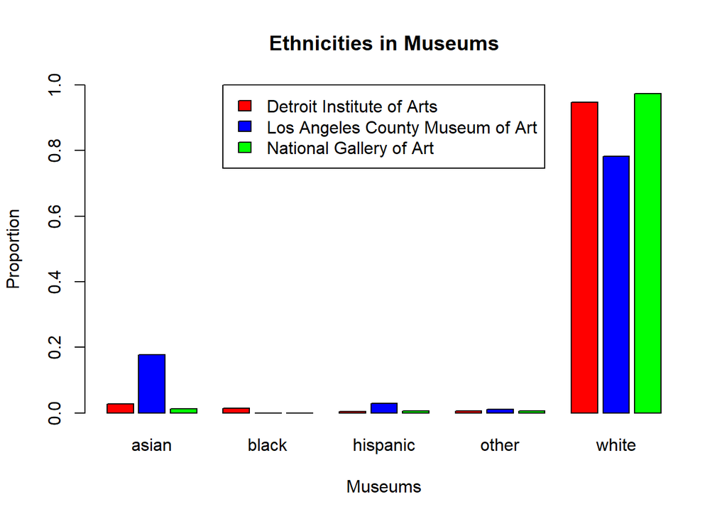

```r
barplot(museum.cond, beside = TRUE, space = c(0.2, 1), ylim = c(0,
    1), col = c("red", "blue", "green"), main = "Ethnicities in Museums",
    xlab = "Museums", ylab = "Proportion", legend = TRUE,
    args.legend = list(x = "top", ncol =1))
```

### c.

```r
chi = chisq.test(museum.counts)
chi$expected
```

```
##
##                                       asian    black hispanic    other
##   Detroit Institute of Arts        41.14460 2.642314 7.171994 4.152207
##   Los Angeles County Museum of Art 42.55479 2.732877 7.417808 4.294521
##   National Gallery of Art          25.30061 1.624810 4.410198 2.553272
##
##                                       white
##   Detroit Institute of Arts        440.8889
##   Los Angeles County Museum of Art 456.0000
##   National Gallery of Art          271.1111
```

### d.

```r
chi
```

```
##
##  Pearson's Chi-squared test
##
## data:  museum.counts
## X-squared = 127.48, df = 8, p-value < 2.2e-16
```

$X^2$ = 127.48 df = 8 p-value = 2.2e-16

### e.

With $\X^2$ = 127.48 and df = 8, we received a p-value of 2.2e-16, which gives us significant evidence to suggest that there is not independence between ethinicity and the meusum. This means that there is significant evidence to believe that the distribution of artist ethnicity differs among the three museums.

### f.

```r
chi$stdres
```

```
##
##                                         asian      black   hispanic
##   Detroit Institute of Arts        -5.6008273  3.4067850 -2.4655958
##   Los Angeles County Museum of Art  9.9325815 -2.1230065  3.5917094
##   National Gallery of Art          -5.0464130 -1.4585229 -1.3192848
##
##                                         other      white
##   Detroit Institute of Arts        -0.7196768  5.2715277
##   Los Angeles County Museum of Art  1.0585126 -9.8965300
##   National Gallery of Art          -0.3967967  5.3828603
```